# Introduction

As you have seen in class, Different types of information can be represented in the shape of networks in order to model the cell. The meaning of the nodes and edges used in a network representation depends on the type of data used to build the network and this should be taken into account when analysing it.

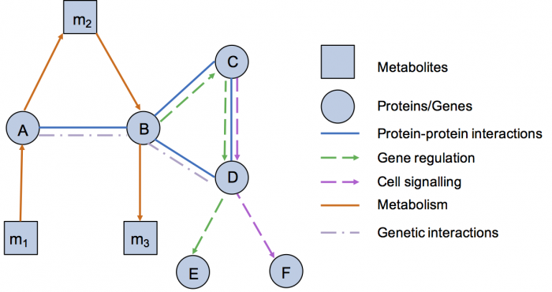

A network with different types of interactions

In practice it is much easier to start with a single interaction type, as you have to make sure that the data are compatible and that you do not introduce bias in your network. The goal of this first practical session is to introduce you to the programmatic approach to building and analyzing networks. We will model the [interactome](https://en.wikipedia.org/wiki/Interactome) starting from a list of all the protein-protein interactions documented for a given organism, analyse its global properties and propose some finer analysis through specific examples.

[figure not shown]

A typical network analysis workflow

# Guided analysis of a protein-protein interaction network

Start by downloading the protein-protein interaction data of the organism of your choice (preferably Homo sapiens or Saccharomyces cerevisiae) from STRING[^1] https://string-db.org/cgi/download.pl (do not download the complete database !). STRING-db is a database of known and predicted interactions based on different types of evidence. In this exercise we will compare two networks : one with only the links with strong experimental evidence and one with the links with high confidence according to their “combined score”, which is constructed partly from indirect evidence such as co-occurence in published abstracts, co-expression etc…

Download the ‘detailed’ file for your chosen organism, which lists all interactions with their subscores (confidence value between 0 and 1000).

You can use bash commands in a terminal to filter the files first instead of importing the whole dataset in R (which uses more RAM).

```bash
# OS X users can use "gawk" instead of "awk"
# Filtering edges on combined score > 900
awk '{if($10>900) print}' 9606.protein.links.detailed.v11.0.txt > human_combined_900.txt
# Filtering edges on experimental score > 900
awk '{if($7>900) print}' 9606.protein.links.detailed.v11.0.txt > human_experimental_900.txt
```

Now you can load those files into R.

## Loading the data and constructing the graph

With the filtered list of edges, construct a graph object that is undirected, unweighted and making sure that there are no duplicated edges. See https://igraph.org/r/doc/aaa-igraph-package.html and https://igraph.org/r/doc/ for help.

```r
library(igraph)
interactions_combined = read.table("human_combined_900.txt", header=T)
interactions_experimental = read.table("human_experimental_900.txt", header=T)
# ... Construct graphs objects :
# See the "graph_from_" functions in the igraph documentation. Do we want a directed graph ? duplicated edges ?
# Save the results in two variables named g_combined and g_experimental. You can access their list of edges with E(g_expermiental)
#and their vertices with V(g_experimental).
```

```r
# OPTIONAL :
# If you want to, you can use custom plot functions like I do
library(ggplot2)
my_hist = function(data, plot_density=FALSE, transform=NULL, theme=theme_classic, vline=NULL){
    varname = deparse(substitute(data))
    plot = ggplot(data.frame(data=data), aes_string(x=data)) +
        xlab(varname) +
        geom_histogram(aes(y=..density..), alpha=0.5, fill='lightblue', color='grey') +
        theme()
    if(plot_density) plot = plot + geom_density()
    if(!is.null(transform)) plot = plot + scale_x_continuous(trans=transform)
    if(!is.null(vline)) plot = plot + geom_vline(xintercept = vline, color='orange')

    plot
}
```

## Early analysis

Now that we have created the graph objects we can begin the analysis. First print the number of vertices(nodes) and edges for each graph have.

```r
# Print the number of vertices and number of edges
```

### Network characteristics

What do the networks look like ? (igraph is not made to plot more than a few hundred nodes, do not try to call `plot` !) Use the theoretical properties seen in the first part to try to define the graph : degree distribution, mean degree (1st neighbours), clustering coefficient…

- Compare the mean and median degrees and clustering coefficient (transitivity) of the two graphs
- Plot the distribution of the degrees of each graph, with a normal histogram and in log-log scale
- Plot the degree of each node in the experimental graph against its degree in the combined score network. Do the same for betweenness and transitivity.

Note that since we created a graph from a list of interactions every node has a degree of at least 1.

```r
combined.degrees = degree(g_combined)
mean(combined.degrees)
```

```
## [1] 41.16004
```

```r
experimental.degrees = degree(g_experimental)
mean(experimental.degrees)
```

```
## [1] 8.866323
```

```r
# ... Plot the degree distribution in log-log scale and the degree
#of each node in experimental vs combined
#
#
```

What can we say about the global and local similarity of the two networks ?

You may have noticed that the networks are in fact not fully connected but consist of several disconnected components. Using the `decompose` and `components` functions, redefine our networks as their biggest connected component before proceeding.

```r
g_combined = decompose(g_combined)[[which.max(components(g_combined)$csize)]]
g_experimental = decompose(g_experimental)[[which.max(components(g_experimental)$csize)]]
```

These networks are the product of evolution, a process that is largely stochastic. But as we saw earlier, there are many ways te randomly generate networks. Using the extracted biggest components, you may try to create random networks with the same number of nodes and edges and compare their characteristics to the observed networks.

```r
N_nodes <- length(V(g_experimental))
N_edges <- length(E(g_experimental))

fit_experimental <- fit_power_law(1+degree(g_experimental, mode="all"), xmin=3)
max_degree <- max(degree(g_experimental))

# Generate two random networks with the same number of vertices and edges, and compare their distributions to the observed PPI network. Which method produces the most lifelike results ?
```

### The first GM babies

In November 2018, He Jiankui (formerly) from the Southern University of Science and Technology of China in Shenzhen claimed to have helped make the world’s first genome-edited babies — [twin girls](https://en.wikipedia.org/wiki/Lulu_and_Nana_controversy), who were born by mid-october 2018. He used the powerful CRISPR–Cas9 genome-editing tool to disable a gene called CCR5, to attempt to confer genetic resistance to the HIV virus.

We will perform a short analysis of the gene in question in the human protein-protein interaction network. First, download the human interaction network from STRING-db if necessary and perform the same steps you have done for loading the data into an igraph object.

The alias of CCR5 is [9606.ENSP00000292303](https://www.uniprot.org/uniprot/P51681) and it is present in our combined_score network. You will retrieve its degree and centrality as measured by various algorithms (try `betweenness`, `eigen_centrality` and `closeness`). Can CCR5 be considered a central hub of the human protein-protein interaction network ?

```r
# Get the CCR5 centrality and compare it to the nodes' centrality values
```

Create a subgraph with CCR5’s immediate neighbours and plot its degree distribution. Does the subgraph centered on CCR5 look like a scale-free network ? Try to find a biological meaning for the observed distribution (You will find more functional information on the STRING website (https://string-db.org/cgi/network.pl?taskId=x7tZxJkWIYqI).

```r
# Custom plot function
plot_graph = function(g, center=NULL){
    V(g)$size = log(degree(g)+1)
    V(g)$frame.color <- "white"
    if(!is.null(center)){
        V(g)$color = 'orange'
        V(g)$color[V(g)$name==center] = 'blue'
    }
    plot(g, vertex.label=NA, edge.width=0.5)
}
```

Now try to expand the subgraph adding the 2nd, 3rd neighbours of CCR5. How fast does the network grow ?

Bonus question : what kind of evidence is there for the interactions of CCR5 with its neighbours?

[^1]: https://www.ncbi.nlm.nih.gov/pmc/articles/PMC539959/